# Lab 11: Decision Trees I: Detecting Fraudulent Transactions EDA

### Learning Objectives

- exploratory data analysis (EDA)
- exploring data depends on context (domain knowledge)
- creating features (predictors)
- review of `group_by()`, `summarize()`, `inner_join()`
- dealing with `NAs` in `summarize()` using `na.rm=TRUE`
- avoid over-plotting with `alpha=..` and `geom_jitter()`

### 1. Introduction

This lab and the next one are adapted from chapter 4 in *Data Mining with R* by Luis Torgo. The data contains over 400 thousand sales reports with the following variables:

- ID - ID of the sales person
- Prod - ID of the product sold
- Quant - number of reported units sold
- Val - reported total value of the sale
- Insp - this variable has three possible values: `ok` if the report was inspected and found valid, `fraud` if the report was inspected but found fraudulent, and `unkn` if the report was not inspected.

### 2. Exploring the data

```r
library(tidyverse)
library(stargazer)
data <- read_csv("sales.csv")
glimpse(data)
```

```
## Observations: 401,146
## Variables: 5
## $ ID    <chr> "v1", "v2", "v3", "v4", "v3", "v5", "v6", "v7", "v8", "v...
## $ Prod  <chr> "p1", "p1", "p1", "p1", "p1", "p2", "p2", "p2", "p2", "p...
## $ Quant <dbl> 182, 3072, 20393, 112, 6164, 104, 350, 200, 233, 118, 23...
## $ Val   <dbl> 1665, 8780, 76990, 1100, 20260, 1155, 5680, 4010, 2855, ...
## $ Insp  <chr> "unkn", "unkn", "unkn", "unkn", "unkn", "unkn", "unkn", ...
```

We see that there are over 400 thousand sales reports. Let’s first look at the quantitative variables: `Val' and`Quant`.

```r
data <- as.data.frame(data)
stargazer(select(data,Val, Quant), type="text", median = TRUE, digits = 0)
```

```
##
## ============================================================================
## Statistic    N     Mean  St. Dev.  Min  Pctl(25) Median Pctl(75)     Max
## ----------------------------------------------------------------------------
## Val       399,964 14,617  69,713  1,005  1,345   2,675   8,680    4,642,955
## Quant     387,304 8,442  918,351   100    107     168     738    473,883,883
## ----------------------------------------------------------------------------
```

There is a pretty wide range in the quantity variable, but it appears that the minimum sale is 100 units. The range in the total value of the sales report is, not surprisingly, also wide and skewed. Also, there are missing values (NA’s) in both quantity and value.

Let’s take a look at the character variables. First, let’s see how many different values each takes on.

```r
n_distinct(data$Prod)
```

```
## [1] 4548
```

```r
n_distinct(data$ID)
```

```
## [1] 6016
```

```r
table(data$Insp)
```

```
##
##  fraud     ok   unkn
##   1270  14462 385414
```

We see that there are lots of different sales people (6,016 of them), and lots of different products (4,548 of them). Importantly, it appears that only a small fraction of reports has been inspected as over 385 thousand reports have unknown status. Of the roughly 15 thousand inspected reports only a small fraction is fraudulent, 8%. Thus, there is significant class imbalance in the variable we are trying to predict. Let’s do a few central tendency statistics by `Insp`.

IN-CLASS EXERCISE 1: Calculate median of value and quantity for ‘ok’, ‘fraudulent’ and ‘unknwn’ transactions.

Hopefully, the above exercise showed that we need to be careful about missing values. Since there are missing values in both `Val` and `Quant` we will use the option `na.rm=TRUE` inside the `mean()` and `median()` functions. This option (`rm` stands for remove) tells `mean()` and `median()` to ignore missing values. Otherwise, if there was any missing value within a group, `mean()` and `median()` would return an `NA`. In other words, we calculate mean and median over all the non-missing values within each group.

```r
sum <- data %>% group_by(Insp) %>%
  summarize(av_Val=mean(Val,na.rm=TRUE), av_Quant=mean(Quant,na.rm=TRUE),
            med_Val=median(Val,na.rm=TRUE), med_Quant=median(Quant,na.rm=TRUE))
sum
```

```
## # A tibble: 3 x 5
##   Insp  av_Val av_Quant med_Val med_Quant
##   <chr>  <dbl>    <dbl>   <dbl>     <dbl>
## 1 fraud 93200.  945504.    6790      737
## 2 ok    60797.   35784.   13635      432.
## 3 unkn  12629.    4260.    2620      166
```

We see that inspected transactions are decidedly larger in terms of value and quantity than uninspected ones (status `unkn`). We see that in terms of *average* value fraudulent transactions are bigger, but in terms of *median* value they appear smaller. Quantity is bigger for fraudulent both in terms of average and median. Clearly, there are some complex relationships among value, quantity and fraudulent/ok status. Let’s plot the data to see if we can shed some light.

We have two quantitative variables, `Val` and `Quant` which we can plot on the x and y axes. We also have qualitative variable `Insp` which we can map to color. Since we saw pretty big range for both value and quantity, we will use log scales. Also, since we have about 400 thousand observations we should reduce over-plotting by making the points transparent using the `alpha=` aesthetic.

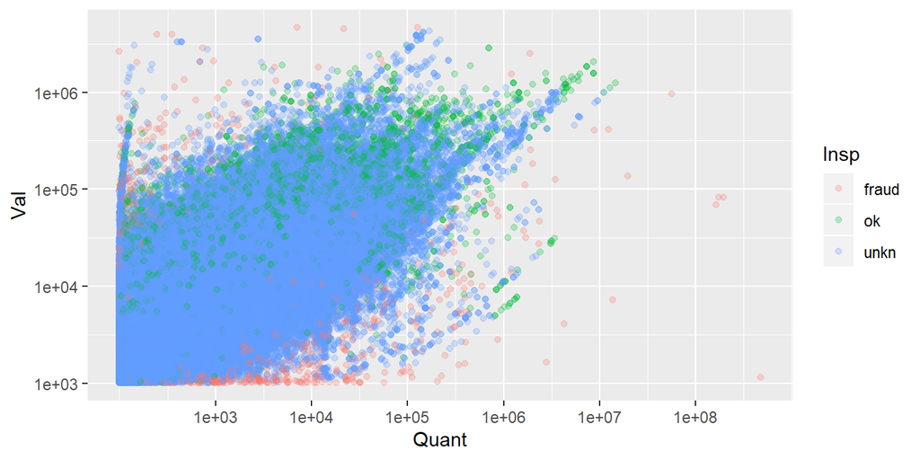

```r
ggplot(data, aes(x=Quant, y=Val, color=Insp)) + geom_point(alpha=0.25) +
  scale_x_continuous(trans="log", breaks=c(1000,10000,100000,1000000,10000000,100000000))+
  scale_y_continuous(trans="log", breaks=c(1000,10000,100000,1000000,10000000))
```

It looks like the fraudulent transactions are scattered around the edges of the ‘cloud’ of observations. They either have high value and low quantity or low value and relatively high quantity. This suggests that unit price (`Val/Quant`) may be unusual for fraudulent transactions.

Let’s examine the unit price for each product. Identical products should cost roughly the same. If there is a big deviation of the unit price from what the product typically sells for, we should probably examine that sales report. To calculate a ‘typical unit price’ we should ideally use only inspected sales reports that were deemed ‘ok’ so that we know the price is accurate. However, only 798 out of total of 4548 products were inspected and deemed ‘ok’. Since the vast majority of reports is ‘ok’ we will use *all* reports that were not fraudulent. Note that we again use the `na.rm=TRUE` option so that we get a typical price (mean or median) for each product even if some reports for a product had missing values for `Val` or `Quant`.

```r
uprice <- data %>% filter(Insp!="fraud") %>% group_by(Prod) %>%
  summarize(av_uprice=mean(Val/Quant,na.rm=TRUE),
            med_uprice=median(Val/Quant,na.rm=TRUE))
uprice <- as.data.frame(uprice)
stargazer(uprice, type="text", median = TRUE, digits =1)
```

```
##
## ====================================================================
## Statistic    N   Mean St. Dev. Min  Pctl(25) Median Pctl(75)   Max
## --------------------------------------------------------------------
## av_uprice  4,546 19.7  129.5   0.1    6.8     13.3    20.4   8,157.3
## med_uprice 4,546 15.0  137.3   0.02   6.0     11.2    15.7   9,204.2
## --------------------------------------------------------------------
```

Given that some of the unit prices may come from fraudulent reports we will use *median* unit price as a measure of a typical price for a product. This may eliminate undue influence of a fraudulent reports. Let’s merge the medium product price back into our data and calculate a relative price as the deviation from median price. We will calculate the deviation from median price as the difference between unit price and the median unit price divided by the average of unit price and median unit price. This method will keep the relative price between -200 and +200 percent. (This will make it easier to visualize.)

```r
data <- full_join(data, uprice, by="Prod") %>%
  mutate(rel_uprice = (Val/Quant-med_uprice)/((Val/Quant+med_uprice)/2)*100)
stargazer(select(filter(data, Insp=="ok"),rel_uprice), median=TRUE, type="text")
```

```
##
## ===========================================================================
## Statistic    N     Mean  St. Dev.   Min    Pctl(25) Median Pctl(75)   Max
## ---------------------------------------------------------------------------
## rel_uprice 14,347 14.623  72.591  -197.683 -36.241  0.412   67.798  196.462
## ---------------------------------------------------------------------------
```

```r
stargazer(select(filter(data, Insp=="fraud"),rel_uprice), median=TRUE, type="text")
```

```
##
## ===========================================================================
## Statistic    N    Mean  St. Dev.   Min    Pctl(25) Median  Pctl(75)   Max
## ---------------------------------------------------------------------------
## rel_uprice 1,199 -0.088 173.075  -200.000 -179.113 -32.933 186.939  199.687
## ---------------------------------------------------------------------------
```

We see that ok transactions tend to have relatively higher unit prices than fraudulent transactions.(I would expect the opposite, i.e. sales people inflating prices.) There is also a big difference in the standard deviation of the relative unit price among the fraudulent transactions versus the ok transactions. Relative prices vary a lot more among the fraudulent transactions. Let’s plot the relative unit prices to get a better sense of how they are distributed withing `ok` and `fraud` transactions. In addition to `alpha` parameter, we can avoid over-plotting by adding a `geom_jitter()` which will add small random shifts the position of our data points. Here we restrict the jitter to horizontal shifts by setting `height=0`.

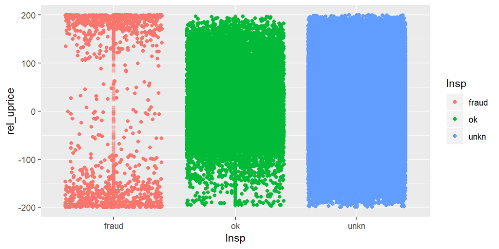

```r
ggplot(data, aes(x=Insp, y=rel_uprice, color=Insp)) + geom_point(alpha=0.25) + geom_jitter(height = 0)
```

Wow, this graph clearly shows that unit prices of fraudulent transactions are off.

```r
data <- data %>%
  mutate(missing = as.factor(case_when(
    is.na(Val) & is.na(Quant) ~ "both missing",
    is.na(Val) ~ "Val missing",
    is.na(Quant) ~ "Quant missing",
    TRUE ~ "no missing")))
table(data$missing)
```

```
##
##  both missing    no missing Quant missing   Val missing
##           888        387010         12954           294
```

We see that missing quantity is much more frequent than missing value. Still, there is probably something suspicious about reports with missing values.

IN-CLASS EXERCISE 2: Create a visual representation of the distribution of observations across values of `Insp` and simultaneously across values of `missing`.

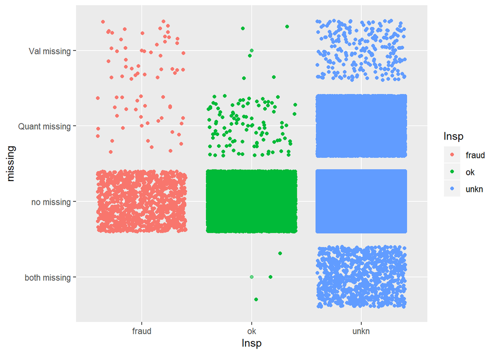

We have at least two solid candidates, `rel_uprice` and `missing`, for predicting fraudulent reports. We will do just that using a new algorithm called decision trees in lab 12.